# Homework 1

## Multivariable plot

In our questionnaire, there are 8 questions about students’ proficiency in 8 categories of software, rating as “None”, “A little”, “Confident” or “Expert”. In order to compare students’ proficiency in different software, we can plot their frequency side-by-side as follows:

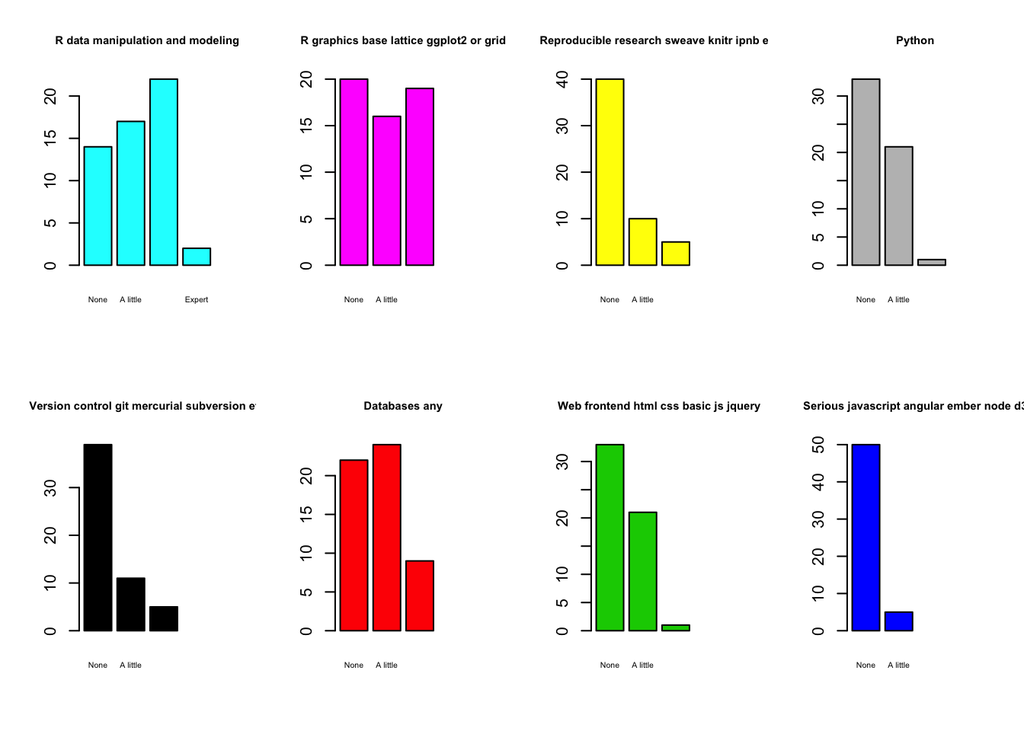

```r
par(mfrow=c(2,4))
ordered <- c("None", "A little", "Confident", "Expert")
for (i in 5:12){
  counti <- table(mques[,i])[ordered]
  listi <- unlist(strsplit(colnames(mques)[i], split="[.]+"))
  titlei <- paste(listi[6:length(listi)], collapse=" ")
  barplot(counti, main=titlei, cex.main=0.7, col=i, cex.names=0.5)
}
```

From the above plots, we can see that there are more students familiar with R data manipulation and R graphics; some students know a little about databses, python or web frontend; but fewer students have some knowledge of version control, reproducible research, and javascript.

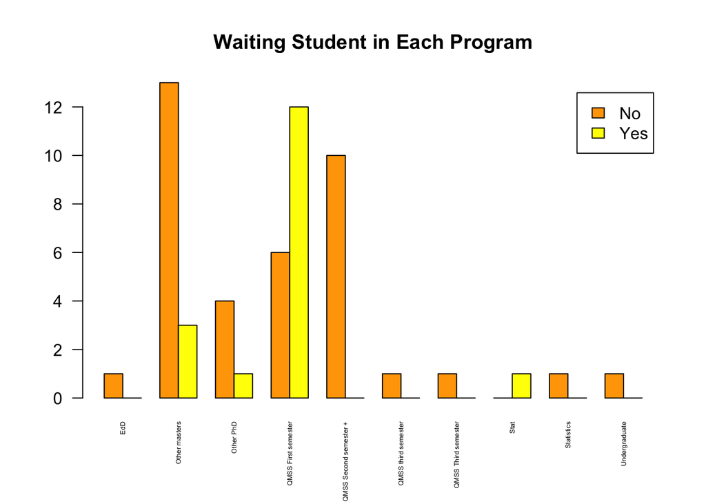

```r
counts <- table(mques$Wait, mques$Program)
barplot(counts, main="Waiting Student in Each Program", col=c("orange","yellow"), legend = rownames(counts), cex.names=0.4, las=2, beside=T)
```